# Marketing Data

```python
import numpy as np
import pandas as pd
```

```python
url = 'https://raw.githubusercontent.com/swapnasavalgi/Marketing-Data/main/marketing_data.csv'
data = pd.read_csv(url)
data
```

|  | ID | Year_Birth | Education | Marital_Status | Income | Kidhome | Teenhome | Dt_Customer | Recency | MntWines | ... | NumStorePurchases | NumWebVisitsMonth | AcceptedCmp3 | AcceptedCmp4 | AcceptedCmp5 | AcceptedCmp1 | AcceptedCmp2 | Response | Complain | Country |
| --- | --- | --- | --- | --- | --- | --- | --- | --- | --- | --- | --- | --- | --- | --- | --- | --- | --- | --- | --- | --- | --- |
| 0 | 1826 | 1970 | Graduation | Divorced | $84,835.00 | 0 | 0 | 6/16/14 | 0 | 189 | ... | 6 | 1 | 0 | 0 | 0 | 0 | 0 | 1 | 0 | SP |
| 1 | 1 | 1961 | Graduation | Single | $57,091.00 | 0 | 0 | 6/15/14 | 0 | 464 | ... | 7 | 5 | 0 | 0 | 0 | 0 | 1 | 1 | 0 | CA |
| 2 | 10476 | 1958 | Graduation | Married | $67,267.00 | 0 | 1 | 5/13/14 | 0 | 134 | ... | 5 | 2 | 0 | 0 | 0 | 0 | 0 | 0 | 0 | US |
| 3 | 1386 | 1967 | Graduation | Together | $32,474.00 | 1 | 1 | 5/11/14 | 0 | 10 | ... | 2 | 7 | 0 | 0 | 0 | 0 | 0 | 0 | 0 | AUS |
| 4 | 5371 | 1989 | Graduation | Single | $21,474.00 | 1 | 0 | 4/8/14 | 0 | 6 | ... | 2 | 7 | 1 | 0 | 0 | 0 | 0 | 1 | 0 | SP |
| 5 | 7348 | 1958 | PhD | Single | $71,691.00 | 0 | 0 | 3/17/14 | 0 | 336 | ... | 5 | 2 | 0 | 0 | 0 | 0 | 0 | 1 | 0 | SP |
| 6 | 4073 | 1954 | 2n Cycle | Married | $63,564.00 | 0 | 0 | 1/29/14 | 0 | 769 | ... | 7 | 6 | 1 | 0 | 0 | 0 | 0 | 1 | 0 | GER |
| 7 | 1991 | 1967 | Graduation | Together | $44,931.00 | 0 | 1 | 1/18/14 | 0 | 78 | ... | 3 | 5 | 0 | 0 | 0 | 0 | 0 | 0 | 0 | SP |
| 8 | 4047 | 1954 | PhD | Married | $65,324.00 | 0 | 1 | 1/11/14 | 0 | 384 | ... | 9 | 4 | 0 | 0 | 0 | 0 | 0 | 0 | 0 | US |
| 9 | 9477 | 1954 | PhD | Married | $65,324.00 | 0 | 1 | 1/11/14 | 0 | 384 | ... | 9 | 4 | 0 | 0 | 0 | 0 | 0 | 0 | 0 | IND |
| 10 | 2079 | 1947 | 2n Cycle | Married | $81,044.00 | 0 | 0 | 12/27/13 | 0 | 450 | ... | 10 | 1 | 0 | 0 | 0 | 0 | 0 | 0 | 0 | US |
| 11 | 5642 | 1979 | Master | Together | $62,499.00 | 1 | 0 | 12/9/13 | 0 | 140 | ... | 6 | 4 | 0 | 0 | 0 | 0 | 0 | 0 | 0 | SP |
| 12 | 10530 | 1959 | PhD | Widow | $67,786.00 | 0 | 0 | 12/7/13 | 0 | 431 | ... | 6 | 1 | 0 | 0 | 0 | 0 | 0 | 1 | 0 | IND |
| 13 | 2964 | 1981 | Graduation | Married | $26,872.00 | 0 | 0 | 10/16/13 | 0 | 3 | ... | 2 | 6 | 0 | 0 | 0 | 0 | 0 | 0 | 0 | CA |
| 14 | 10311 | 1969 | Graduation | Married | $4,428.00 | 0 | 1 | 10/5/13 | 0 | 16 | ... | 0 | 1 | 0 | 0 | 0 | 0 | 0 | 0 | 0 | SP |
| 15 | 837 | 1977 | Graduation | Married | $54,809.00 | 1 | 1 | 9/11/13 | 0 | 63 | ... | 5 | 4 | 0 | 0 | 0 | 0 | 0 | 0 | 0 | SP |
| 16 | 10521 | 1977 | Graduation | Married | $54,809.00 | 1 | 1 | 9/11/13 | 0 | 63 | ... | 5 | 4 | 0 | 0 | 0 | 0 | 0 | 1 | 0 | SP |
| 17 | 10175 | 1958 | PhD | Divorced | $32,173.00 | 0 | 1 | 8/1/13 | 0 | 18 | ... | 3 | 4 | 0 | 0 | 0 | 0 | 0 | 0 | 0 | SP |
| 18 | 1473 | 1960 | 2n Cycle | Single | $47,823.00 | 0 | 1 | 7/23/13 | 0 | 53 | ... | 3 | 8 | 0 | 0 | 0 | 0 | 0 | 0 | 0 | CA |
| 19 | 2795 | 1958 | Master | Single | $30,523.00 | 2 | 1 | 7/1/13 | 0 | 5 | ... | 2 | 7 | 0 | 0 | 0 | 0 | 0 | 0 | 0 | CA |
| 20 | 2285 | 1954 | Master | Together | $36,634.00 | 0 | 1 | 5/28/13 | 0 | 213 | ... | 5 | 7 | 0 | 0 | 0 | 0 | 0 | 0 | 0 | SA |
| 21 | 115 | 1966 | Master | Single | $43,456.00 | 0 | 1 | 3/26/13 | 0 | 275 | ... | 8 | 5 | 0 | 0 | 0 | 0 | 0 | 0 | 0 | IND |
| 22 | 10470 | 1979 | Master | Married | $40,662.00 | 1 | 0 | 3/15/13 | 0 | 40 | ... | 3 | 4 | 0 | 0 | 0 | 0 | 0 | 0 | 0 | GER |
| 23 | 4065 | 1976 | PhD | Married | $49,544.00 | 1 | 0 | 2/12/13 | 0 | 308 | ... | 8 | 7 | 0 | 0 | 0 | 0 | 0 | 0 | 0 | SP |
| 24 | 10968 | 1969 | Graduation | Single | $57,731.00 | 0 | 1 | 11/23/12 | 0 | 266 | ... | 6 | 6 | 0 | 0 | 0 | 0 | 0 | 0 | 0 | IND |
| 25 | 5985 | 1965 | Master | Single | $33,168.00 | 0 | 1 | 10/13/12 | 0 | 80 | ... | 4 | 7 | 0 | 0 | 0 | 0 | 0 | 0 | 0 | SP |
| 26 | 5430 | 1956 | Graduation | Together | $54,450.00 | 1 | 1 | 9/14/12 | 0 | 454 | ... | 8 | 8 | 0 | 0 | 0 | 0 | 0 | 0 | 0 | SP |
| 27 | 8432 | 1956 | Graduation | Together | $54,450.00 | 1 | 1 | 9/14/12 | 0 | 454 | ... | 8 | 8 | 0 | 0 | 0 | 0 | 0 | 0 | 0 | SP |
| 28 | 453 | 1956 | PhD | Widow | $35,340.00 | 1 | 1 | 6/29/14 | 1 | 27 | ... | 3 | 5 | 0 | 0 | 0 | 0 | 0 | 0 | 0 | SP |
| 29 | 9687 | 1975 | Graduation | Single | $73,170.00 | 0 | 0 | 5/31/14 | 1 | 184 | ... | 6 | 2 | 0 | 0 | 0 | 0 | 0 | 0 | 0 | CA |
| ... | ... | ... | ... | ... | ... | ... | ... | ... | ... | ... | ... | ... | ... | ... | ... | ... | ... | ... | ... | ... | ... |
| 2210 | 966 | 1966 | Graduation | Married | $44,529.00 | 0 | 1 | 7/5/13 | 98 | 538 | ... | 11 | 5 | 0 | 1 | 0 | 0 | 0 | 0 | 0 | SP |
| 2211 | 9706 | 1974 | PhD | Single | $31,560.00 | 1 | 0 | 6/24/13 | 98 | 62 | ... | 3 | 8 | 0 | 0 | 0 | 0 | 0 | 0 | 0 | CA |
| 2212 | 3979 | 1983 | PhD | Divorced | $90,687.00 | 0 | 0 | 5/22/13 | 98 | 982 | ... | 8 | 2 | 0 | 0 | 1 | 0 | 0 | 1 | 0 | SP |
| 2213 | 5602 | 1989 | PhD | Together | $66,973.00 | 0 | 0 | 5/17/13 | 98 | 466 | ... | 12 | 3 | 0 | 0 | 0 | 0 | 0 | 0 | 0 | IND |
| 2214 | 2202 | 1978 | Graduation | Together | $41,154.00 | 0 | 1 | 4/9/13 | 98 | 44 | ... | 4 | 5 | 0 | 0 | 0 | 0 | 0 | 0 | 0 | SP |
| 2215 | 9645 | 1968 | Graduation | Married | $64,590.00 | 0 | 0 | 10/14/12 | 98 | 920 | ... | 10 | 6 | 0 | 0 | 0 | 0 | 0 | 0 | 0 | SP |
| 2216 | 7230 | 1960 | PhD | Divorced | $50,611.00 | 0 | 1 | 10/4/12 | 98 | 459 | ... | 7 | 6 | 0 | 1 | 0 | 0 | 0 | 1 | 0 | US |
| 2217 | 5675 | 1960 | PhD | Divorced | $50,611.00 | 0 | 1 | 10/4/12 | 98 | 459 | ... | 7 | 6 | 0 | 1 | 0 | 0 | 0 | 0 | 0 | US |
| 2218 | 4974 | 1970 | Graduation | Single | $83,273.00 | 1 | 2 | 9/25/12 | 98 | 433 | ... | 9 | 7 | 0 | 0 | 0 | 0 | 0 | 0 | 0 | US |
| 2219 | 5687 | 1980 | Graduation | Divorced | $81,702.00 | 0 | 0 | 9/23/12 | 98 | 563 | ... | 12 | 3 | 0 | 0 | 0 | 0 | 0 | 0 | 0 | CA |
| 2220 | 5871 | 1979 | Master | Together | $24,401.00 | 0 | 0 | 8/31/12 | 98 | 73 | ... | 6 | 8 | 0 | 0 | 0 | 0 | 0 | 0 | 0 | SA |
| 2221 | 3846 | 1974 | Graduation | Married | $42,557.00 | 0 | 1 | 8/29/12 | 98 | 192 | ... | 4 | 8 | 0 | 0 | 0 | 0 | 0 | 0 | 0 | SP |
| 2222 | 10001 | 1985 | 2n Cycle | Together | $7,500.00 | 1 | 0 | 8/1/12 | 98 | 5 | ... | 3 | 9 | 0 | 0 | 0 | 0 | 0 | 0 | 0 | SP |
| 2223 | 2831 | 1976 | Graduation | Together | $78,416.00 | 0 | 1 | 6/27/14 | 99 | 453 | ... | 10 | 3 | 0 | 0 | 0 | 0 | 0 | 0 | 0 | SP |
| 2224 | 868 | 1966 | Graduation | Married | $44,794.00 | 0 | 1 | 6/8/14 | 99 | 54 | ... | 3 | 6 | 0 | 0 | 0 | 0 | 0 | 0 | 0 | SA |
| 2225 | 7212 | 1966 | Graduation | Married | $44,794.00 | 0 | 1 | 6/8/14 | 99 | 54 | ... | 3 | 6 | 0 | 0 | 0 | 0 | 0 | 0 | 0 | AUS |
| 2226 | 1743 | 1974 | Graduation | Single | $69,719.00 | 0 | 0 | 5/26/14 | 99 | 273 | ... | 5 | 1 | 0 | 0 | 0 | 0 | 0 | 0 | 0 | SP |
| 2227 | 2415 | 1962 | Graduation | Together | $62,568.00 | 0 | 1 | 4/7/14 | 99 | 362 | ... | 5 | 4 | 0 | 0 | 0 | 1 | 0 | 0 | 0 | SP |
| 2228 | 7947 | 1969 | Graduation | Married | $42,231.00 | 1 | 1 | 3/25/14 | 99 | 24 | ... | 3 | 5 | 0 | 0 | 0 | 0 | 0 | 0 | 0 | SP |
| 2229 | 2106 | 1974 | 2n Cycle | Married | $20,130.00 | 0 | 0 | 3/17/14 | 99 | 0 | ... | 3 | 8 | 0 | 0 | 0 | 0 | 0 | 0 | 0 | SP |
| 2230 | 3363 | 1974 | 2n Cycle | Married | $20,130.00 | 0 | 0 | 3/17/14 | 99 | 0 | ... | 3 | 8 | 0 | 0 | 0 | 0 | 0 | 0 | 0 | SP |
| 2231 | 8595 | 1973 | Graduation | Widow | $42,429.00 | 0 | 1 | 2/11/14 | 99 | 55 | ... | 3 | 5 | 0 | 0 | 0 | 0 | 0 | 0 | 0 | AUS |
| 2232 | 7232 | 1973 | Graduation | Widow | $42,429.00 | 0 | 1 | 2/11/14 | 99 | 55 | ... | 3 | 5 | 0 | 0 | 0 | 0 | 0 | 0 | 0 | SP |
| 2233 | 7829 | 1900 | 2n Cycle | Divorced | $36,640.00 | 1 | 0 | 9/26/13 | 99 | 15 | ... | 2 | 5 | 0 | 0 | 0 | 0 | 0 | 0 | 1 | IND |
| 2234 | 9977 | 1973 | Graduation | Divorced | $78,901.00 | 0 | 1 | 9/17/13 | 99 | 321 | ... | 5 | 4 | 0 | 0 | 0 | 0 | 0 | 0 | 0 | US |
| 2235 | 10142 | 1976 | PhD | Divorced | $66,476.00 | 0 | 1 | 3/7/13 | 99 | 372 | ... | 11 | 4 | 0 | 0 | 0 | 0 | 0 | 0 | 0 | US |
| 2236 | 5263 | 1977 | 2n Cycle | Married | $31,056.00 | 1 | 0 | 1/22/13 | 99 | 5 | ... | 3 | 8 | 0 | 0 | 0 | 0 | 0 | 0 | 0 | SP |
| 2237 | 22 | 1976 | Graduation | Divorced | $46,310.00 | 1 | 0 | 12/3/12 | 99 | 185 | ... | 5 | 8 | 0 | 0 | 0 | 0 | 0 | 0 | 0 | SP |
| 2238 | 528 | 1978 | Graduation | Married | $65,819.00 | 0 | 0 | 11/29/12 | 99 | 267 | ... | 10 | 3 | 0 | 0 | 0 | 0 | 0 | 0 | 0 | IND |
| 2239 | 4070 | 1969 | PhD | Married | $94,871.00 | 0 | 2 | 9/1/12 | 99 | 169 | ... | 4 | 7 | 0 | 1 | 1 | 0 | 0 | 1 | 0 | CA |

2240 rows × 28 columns

```python
missing_values = data.isnull().sum()
missing_values
```

```
ID                      0
Year_Birth              0
Education               0
Marital_Status          0
 Income                24
Kidhome                 0
Teenhome                0
Dt_Customer             0
Recency                 0
MntWines                0
MntFruits               0
MntMeatProducts         0
MntFishProducts         0
MntSweetProducts        0
MntGoldProds            0
NumDealsPurchases       0
NumWebPurchases         0
NumCatalogPurchases     0
NumStorePurchases       0
NumWebVisitsMonth       0
AcceptedCmp3            0
AcceptedCmp4            0
AcceptedCmp5            0
AcceptedCmp1            0
AcceptedCmp2            0
Response                0
Complain                0
Country                 0
dtype: int64
```

```python
data.info()
```

```
<class 'pandas.core.frame.DataFrame'>
RangeIndex: 2240 entries, 0 to 2239
Data columns (total 28 columns):
ID                     2240 non-null int64
Year_Birth             2240 non-null int64
Education              2240 non-null object
Marital_Status         2240 non-null object
 Income                2216 non-null object
Kidhome                2240 non-null int64
Teenhome               2240 non-null int64
Dt_Customer            2240 non-null object
Recency                2240 non-null int64
MntWines               2240 non-null int64
MntFruits              2240 non-null int64
MntMeatProducts        2240 non-null int64
MntFishProducts        2240 non-null int64
MntSweetProducts       2240 non-null int64
MntGoldProds           2240 non-null int64
NumDealsPurchases      2240 non-null int64
NumWebPurchases        2240 non-null int64
NumCatalogPurchases    2240 non-null int64
NumStorePurchases      2240 non-null int64
NumWebVisitsMonth      2240 non-null int64
AcceptedCmp3           2240 non-null int64
AcceptedCmp4           2240 non-null int64
AcceptedCmp5           2240 non-null int64
AcceptedCmp1           2240 non-null int64
AcceptedCmp2           2240 non-null int64
Response               2240 non-null int64
Complain               2240 non-null int64
Country                2240 non-null object
dtypes: int64(23), object(5)
memory usage: 490.1+ KB
```

There are 5 categorical variables and 23 numerical variables

```python
#Removing the space from "Income" var

data.rename(columns={' Income ':'Income'},inplace=True)
data.info()
```

```
<class 'pandas.core.frame.DataFrame'>
RangeIndex: 2240 entries, 0 to 2239
Data columns (total 28 columns):
ID                     2240 non-null int64
Year_Birth             2240 non-null int64
Education              2240 non-null object
Marital_Status         2240 non-null object
Income                 2216 non-null object
Kidhome                2240 non-null int64
Teenhome               2240 non-null int64
Dt_Customer            2240 non-null object
Recency                2240 non-null int64
MntWines               2240 non-null int64
MntFruits              2240 non-null int64
MntMeatProducts        2240 non-null int64
MntFishProducts        2240 non-null int64
MntSweetProducts       2240 non-null int64
MntGoldProds           2240 non-null int64
NumDealsPurchases      2240 non-null int64
NumWebPurchases        2240 non-null int64
NumCatalogPurchases    2240 non-null int64
NumStorePurchases      2240 non-null int64
NumWebVisitsMonth      2240 non-null int64
AcceptedCmp3           2240 non-null int64
AcceptedCmp4           2240 non-null int64
AcceptedCmp5           2240 non-null int64
AcceptedCmp1           2240 non-null int64
AcceptedCmp2           2240 non-null int64
Response               2240 non-null int64
Complain               2240 non-null int64
Country                2240 non-null object
dtypes: int64(23), object(5)
memory usage: 490.1+ KB
```

```python
data["Income"] = data["Income"].str.replace("$", "").str.replace(",","")
data['Income'] = data['Income'].astype('float')
```

```python
#Adding a new variable to replace year_birth to Age.
data['Age'] = 2021 - data['Year_Birth']
```

```python
#Combining below variables into one.

data['Spending'] = data['MntWines'] + data['MntFruits']+data['MntMeatProducts']+data['MntFishProducts']+data['MntSweetProducts']+data['MntGoldProds']
```

```python
data['Marital_Status'].value_counts()
```

```
Married     864
Together    580
Single      480
Divorced    232
Widow        77
Alone         3
YOLO          2
Absurd        2
Name: Marital_Status, dtype: int64
```

```python
import seaborn as sns
import matplotlib.pyplot as plt
```

```python
data['Marital_Status'] = data['Marital_Status'].replace({'Together':'In Couple','Married':'In Couple', 'Single':'Alone', 'Widow':'Alone','Divorced':'Alone','Absurd':'Alone','YOLO':'Alone' })
```

```python
data['Marital_Status'].value_counts()
```

```
In Couple    1444
Alone         796
Name: Marital_Status, dtype: int64
```

```python
data['Has_child'] = np.where(data['Kidhome'] + data['Teenhome'] > 0 , 'Yes','No')
```

```python
data['Education'].value_counts()
```

```
Graduation    1127
PhD            486
Master         370
2n Cycle       203
Basic           54
Name: Education, dtype: int64
```

```python
#Variable Educationnal_years as the total number of years of education the individual achieved according to its diploma

data['Educational_years'] = data['Education'].replace({'Basic':5,'2n Cycle':8,'Graduation':12,'Master':18,'PhD':21})
```

```python
#Creting an new dataaframe

data_new = data[['Age','Income','Spending','Marital_Status','Has_child','Educational_years', 'Education']]
data_new.head()
```

|  | Age | Income | Spending | Marital_Status | Has_child | Educational_years | Education |
| --- | --- | --- | --- | --- | --- | --- | --- |
| 0 | 51 | 84835.0 | 1190 | Alone | No | 12 | Graduation |
| 1 | 60 | 57091.0 | 577 | Alone | No | 12 | Graduation |
| 2 | 63 | 67267.0 | 251 | In Couple | Yes | 12 | Graduation |
| 3 | 54 | 32474.0 | 11 | In Couple | Yes | 12 | Graduation |
| 4 | 32 | 21474.0 | 91 | Alone | Yes | 12 | Graduation |

Statistical Summary

```python
pd.options.display.float_format = "{:.2f}".format

data_new.describe()
```

|  | Age | Income | Spending | Educational_years |
| --- | --- | --- | --- | --- |
| count | 2240.00 | 2216.00 | 2240.00 | 2240.00 |
| mean | 52.19 | 52247.25 | 605.80 | 14.41 |
| std | 11.98 | 25173.08 | 602.25 | 4.51 |
| min | 25.00 | 1730.00 | 5.00 | 5.00 |
| 25% | 44.00 | 35303.00 | 68.75 | 12.00 |
| 50% | 51.00 | 51381.50 | 396.00 | 12.00 |
| 75% | 62.00 | 68522.00 | 1045.50 | 18.00 |
| max | 128.00 | 666666.00 | 2525.00 | 21.00 |

- Average income is 52247 while median 51381 dollars.The distribution is right skewed with possible presence of outliers
- Average spending is 605 $ while median is 396 dollars
- Average age is 52 and the oldest customer's age is 128 which is pretty rare event .
- Average Educational_Years is 14 which corresponds to Bachelors degree

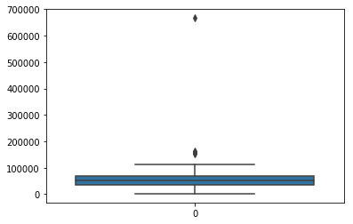

```python
sns.boxplot(data= data_new['Income'])
```

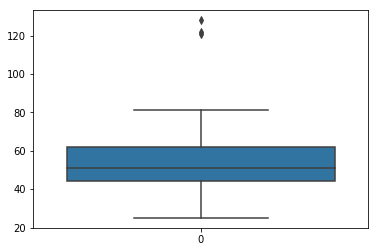

```python
sns.boxplot(data= data_new['Age'])
```

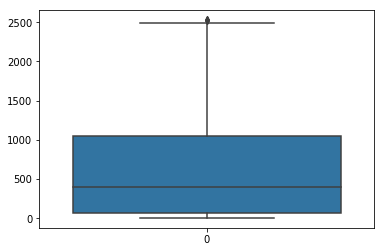

```python
sns.boxplot(data= data_new['Spending'])
```

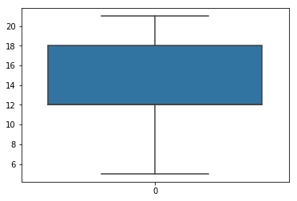

```python
sns.boxplot(data= data_new['Educational_years'])
```

```python
dataset = data_new.drop(data_new[data_new['Income']>60000].index).reset_index(drop = True)
dataset
```

|  | Age | Income | Spending | Marital_Status | Has_child | Educational_years | Education |
| --- | --- | --- | --- | --- | --- | --- | --- |
| 0 | 60 | 57091.00 | 577 | Alone | No | 12 | Graduation |
| 1 | 54 | 32474.00 | 11 | In Couple | Yes | 12 | Graduation |
| 2 | 32 | 21474.00 | 91 | Alone | Yes | 12 | Graduation |
| 3 | 54 | 44931.00 | 96 | In Couple | Yes | 12 | Graduation |
| 4 | 40 | 26872.00 | 72 | In Couple | No | 12 | Graduation |
| 5 | 52 | 4428.00 | 359 | In Couple | Yes | 12 | Graduation |
| 6 | 44 | 54809.00 | 174 | In Couple | Yes | 12 | Graduation |
| 7 | 44 | 54809.00 | 174 | In Couple | Yes | 12 | Graduation |
| 8 | 63 | 32173.00 | 22 | Alone | Yes | 21 | PhD |
| 9 | 61 | 47823.00 | 72 | Alone | Yes | 8 | 2n Cycle |
| 10 | 63 | 30523.00 | 13 | Alone | Yes | 18 | Master |
| 11 | 67 | 36634.00 | 335 | In Couple | Yes | 18 | Master |
| 12 | 55 | 43456.00 | 393 | Alone | Yes | 18 | Master |
| 13 | 42 | 40662.00 | 92 | In Couple | Yes | 18 | Master |
| 14 | 45 | 49544.00 | 404 | In Couple | Yes | 21 | PhD |
| 15 | 52 | 57731.00 | 704 | Alone | Yes | 12 | Graduation |
| 16 | 56 | 33168.00 | 122 | Alone | Yes | 18 | Master |
| 17 | 65 | 54450.00 | 684 | In Couple | Yes | 12 | Graduation |
| 18 | 65 | 54450.00 | 684 | In Couple | Yes | 12 | Graduation |
| 19 | 65 | 35340.00 | 45 | Alone | Yes | 21 | PhD |
| 20 | 49 | 34578.00 | 8 | In Couple | Yes | 21 | PhD |
| 21 | 47 | 46374.00 | 446 | In Couple | Yes | 21 | PhD |
| 22 | 31 | 18351.00 | 43 | In Couple | No | 12 | Graduation |
| 23 | 61 | 39228.00 | 20 | Alone | No | 18 | Master |
| 24 | 49 | 21359.00 | 48 | Alone | Yes | 12 | Graduation |
| 25 | 35 | 39146.00 | 165 | Alone | Yes | 12 | Graduation |
| 26 | 51 | 25959.00 | 56 | Alone | Yes | 8 | 2n Cycle |
| 27 | 48 | 32300.00 | 39 | In Couple | Yes | 12 | Graduation |
| 28 | 61 | 48904.00 | 371 | Alone | Yes | 12 | Graduation |
| 29 | 37 | 14796.00 | 51 | In Couple | Yes | 8 | 2n Cycle |
| ... | ... | ... | ... | ... | ... | ... | ... |
| 1369 | 43 | 34043.00 | 49 | In Couple | Yes | 21 | PhD |
| 1370 | 56 | 54111.00 | 388 | Alone | Yes | 21 | PhD |
| 1371 | 40 | 39665.00 | 216 | In Couple | Yes | 21 | PhD |
| 1372 | 37 | 38680.00 | 79 | In Couple | Yes | 12 | Graduation |
| 1373 | 37 | 24570.00 | 193 | In Couple | Yes | 12 | Graduation |
| 1374 | 53 | 23748.00 | 76 | Alone | Yes | 18 | Master |
| 1375 | 57 | 45989.00 | 322 | Alone | Yes | 12 | Graduation |
| 1376 | 33 | 23331.00 | 269 | Alone | Yes | 8 | 2n Cycle |
| 1377 | 58 | 23091.00 | 48 | Alone | Yes | 21 | PhD |
| 1378 | 31 | 24683.00 | 41 | In Couple | Yes | 8 | 2n Cycle |
| 1379 | 48 | 54222.00 | 264 | In Couple | Yes | 21 | PhD |
| 1380 | 43 | 47025.00 | 635 | In Couple | Yes | 8 | 2n Cycle |
| 1381 | 55 | 44529.00 | 691 | In Couple | Yes | 12 | Graduation |
| 1382 | 47 | 31560.00 | 94 | Alone | Yes | 21 | PhD |
| 1383 | 43 | 41154.00 | 69 | In Couple | Yes | 12 | Graduation |
| 1384 | 61 | 50611.00 | 493 | Alone | Yes | 21 | PhD |
| 1385 | 61 | 50611.00 | 493 | Alone | Yes | 21 | PhD |
| 1386 | 42 | 24401.00 | 467 | In Couple | No | 18 | Master |
| 1387 | 47 | 42557.00 | 270 | In Couple | Yes | 12 | Graduation |
| 1388 | 36 | 7500.00 | 100 | In Couple | Yes | 8 | 2n Cycle |
| 1389 | 55 | 44794.00 | 65 | In Couple | Yes | 12 | Graduation |
| 1390 | 55 | 44794.00 | 65 | In Couple | Yes | 12 | Graduation |
| 1391 | 52 | 42231.00 | 37 | In Couple | Yes | 12 | Graduation |
| 1392 | 47 | 20130.00 | 34 | In Couple | No | 8 | 2n Cycle |
| 1393 | 47 | 20130.00 | 34 | In Couple | No | 8 | 2n Cycle |
| 1394 | 48 | 42429.00 | 67 | Alone | Yes | 12 | Graduation |
| 1395 | 48 | 42429.00 | 67 | Alone | Yes | 12 | Graduation |
| 1396 | 121 | 36640.00 | 65 | Alone | Yes | 8 | 2n Cycle |
| 1397 | 44 | 31056.00 | 55 | In Couple | Yes | 8 | 2n Cycle |
| 1398 | 45 | 46310.00 | 309 | Alone | Yes | 12 | Graduation |

1399 rows × 7 columns

```python
dataset.fillna(dataset.mean(), inplace = True)
```

```python
missing = dataset['Income'].isnull().sum()
missing
```

```
0
```

```python
import sklearn
from sklearn.linear_model import LinearRegression
from scipy.stats import shapiro
from scipy.stats import chi2
from scipy.stats import chi2_contingency
import scipy.stats as stats
from numpy import median
from numpy import std
from scipy.stats import normaltest
```

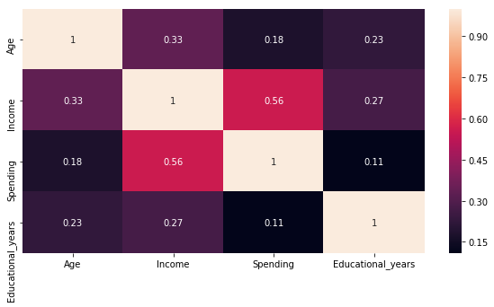

```python
plt.figure(figsize = (10,5))
sns.heatmap(dataset.corr(), annot = True)
```

# Statistical Hypothesis Testing

If the average salary of a Phd is statistically different than MS? Is the correlation between annual income and spendings statistically significant?

- Test for Normality

Statistical methods are divided into two parts:

- Non parametric (If data is not normally distributed)
- Parametric (If data is normally distributed)

```python
# Graphically it can be shown in histogram

df = pd.DataFrame(dataset, columns = [ 'Age','Income','Spending','Educational_years'])
df
```

|  | Age | Income | Spending | Educational_years |
| --- | --- | --- | --- | --- |
| 0 | 60 | 57091.00 | 577 | 12 |
| 1 | 54 | 32474.00 | 11 | 12 |
| 2 | 32 | 21474.00 | 91 | 12 |
| 3 | 54 | 44931.00 | 96 | 12 |
| 4 | 40 | 26872.00 | 72 | 12 |
| 5 | 52 | 4428.00 | 359 | 12 |
| 6 | 44 | 54809.00 | 174 | 12 |
| 7 | 44 | 54809.00 | 174 | 12 |
| 8 | 63 | 32173.00 | 22 | 21 |
| 9 | 61 | 47823.00 | 72 | 8 |
| 10 | 63 | 30523.00 | 13 | 18 |
| 11 | 67 | 36634.00 | 335 | 18 |
| 12 | 55 | 43456.00 | 393 | 18 |
| 13 | 42 | 40662.00 | 92 | 18 |
| 14 | 45 | 49544.00 | 404 | 21 |
| 15 | 52 | 57731.00 | 704 | 12 |
| 16 | 56 | 33168.00 | 122 | 18 |
| 17 | 65 | 54450.00 | 684 | 12 |
| 18 | 65 | 54450.00 | 684 | 12 |
| 19 | 65 | 35340.00 | 45 | 21 |
| 20 | 49 | 34578.00 | 8 | 21 |
| 21 | 47 | 46374.00 | 446 | 21 |
| 22 | 31 | 18351.00 | 43 | 12 |
| 23 | 61 | 39228.00 | 20 | 18 |
| 24 | 49 | 21359.00 | 48 | 12 |
| 25 | 35 | 39146.00 | 165 | 12 |
| 26 | 51 | 25959.00 | 56 | 8 |
| 27 | 48 | 32300.00 | 39 | 12 |
| 28 | 61 | 48904.00 | 371 | 12 |
| 29 | 37 | 14796.00 | 51 | 8 |
| ... | ... | ... | ... | ... |
| 1369 | 43 | 34043.00 | 49 | 21 |
| 1370 | 56 | 54111.00 | 388 | 21 |
| 1371 | 40 | 39665.00 | 216 | 21 |
| 1372 | 37 | 38680.00 | 79 | 12 |
| 1373 | 37 | 24570.00 | 193 | 12 |
| 1374 | 53 | 23748.00 | 76 | 18 |
| 1375 | 57 | 45989.00 | 322 | 12 |
| 1376 | 33 | 23331.00 | 269 | 8 |
| 1377 | 58 | 23091.00 | 48 | 21 |
| 1378 | 31 | 24683.00 | 41 | 8 |
| 1379 | 48 | 54222.00 | 264 | 21 |
| 1380 | 43 | 47025.00 | 635 | 8 |
| 1381 | 55 | 44529.00 | 691 | 12 |
| 1382 | 47 | 31560.00 | 94 | 21 |
| 1383 | 43 | 41154.00 | 69 | 12 |
| 1384 | 61 | 50611.00 | 493 | 21 |
| 1385 | 61 | 50611.00 | 493 | 21 |
| 1386 | 42 | 24401.00 | 467 | 18 |
| 1387 | 47 | 42557.00 | 270 | 12 |
| 1388 | 36 | 7500.00 | 100 | 8 |
| 1389 | 55 | 44794.00 | 65 | 12 |
| 1390 | 55 | 44794.00 | 65 | 12 |
| 1391 | 52 | 42231.00 | 37 | 12 |
| 1392 | 47 | 20130.00 | 34 | 8 |
| 1393 | 47 | 20130.00 | 34 | 8 |
| 1394 | 48 | 42429.00 | 67 | 12 |
| 1395 | 48 | 42429.00 | 67 | 12 |
| 1396 | 121 | 36640.00 | 65 | 8 |
| 1397 | 44 | 31056.00 | 55 | 8 |
| 1398 | 45 | 46310.00 | 309 | 12 |

1399 rows × 4 columns

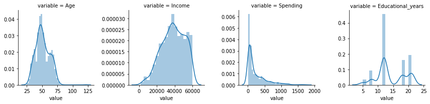

```python
nd = pd.melt(df, value_vars= df)
n1 = sns.FacetGrid(nd, col = 'variable',col_wrap = 4, sharex = False, sharey=False)
n1 = n1.map(sns.distplot,'value')
n1
```

# skeweness

```python
from scipy.stats import skew

df.skew(axis = 0, skipna = True)
```

```
Age                  0.36
Income              -0.30
Spending             1.91
Educational_years    0.16
dtype: float64
```

- skewness == 0 normally distributed
- skewness > 0 : right skewed
- skewness < 0 : left skewed

Here Spending is skewed right and Income is skewed left . Educational years and Age is not perfectly symetric but it slowly skewed right .